# Deney Tasarımı Proje Ödevi

Assiye Sevde ÖZATA

28 05 2021

Veri Seti:https://www.kaggle.com/saurabhshahane/food-consumption-in-indonesia?select=+DATASET+cultural+dimension+of+food+consumption.xlsx

Bu veri seti, Endonezya’daki kentsel topluluklarda gıda tüketim kalıplarının kültürel boyutunun özelliklerine ilişkin anket verilerini göstermektedir.

```r
library(readxl)
DATASET_cultural_dimension_of_food_consumption <-read_excel("C:/Users/sevde/OneDrive/Masaüstü/DATASET_cultural dimension of food consumption.xlsx")
View(DATASET_cultural_dimension_of_food_consumption)
head(DATASET_cultural_dimension_of_food_consumption)
```

```
## # A tibble: 6 x 28
##   `(A1) CITY` `(A2) PROVINCE` `(B3) GENDER` `(B4) AGE` `(B5) RELIGION`
##   <chr>       <chr>           <chr>              <dbl> <chr>
## 1 Jakarta     DKI Jakarta     Female                31 Islam
## 2 Jakarta     DKI Jakarta     Female                36 Islam
## 3 Jakarta     DKI Jakarta     Male                  24 Islam
## 4 Jakarta     DKI Jakarta     Female                63 Islam
## 5 Jakarta     DKI Jakarta     Male                  43 Protestant
## 6 Jakarta     DKI Jakarta     Female                47 Protestant
## # ... with 23 more variables: (B6) ETHNIC <chr>, (B7) EDUCATION LEVEL <chr>,
## #   (B8) LIVED IN URBAN AREA (YEARS) <dbl>, (B9) OCCUPATION <chr>,
## #   (B10) SOCIAL CLAS <chr>, (B11) HOUSEHOLD MEMBER <dbl>,
## #   (C12) HOUSEHOLD INCOME (MONTHLY IN MILLION IDR) <dttm>,
## #   (C13) TIME OF INCOME RECEIPT <chr>,
## #   (C14) HOUSEHOLD EXPENDITURE (MONTHLY IN MILLION IDR) <dttm>,
## #   (C15) % MONTHLY EXPENDITURE FOR FOOD <dbl>, (D16) HEALTH FACTOR <chr>,
## #   (D17) PRICE FACTOR) <chr>, (E18) RELIGIOUS VALUE IN TYPE OF FOOD <chr>,
## #   (E19) RELIGIOUS VALUE IN EATING PLACES <chr>,
## #   (E20) RELIGIOUS VALUE IN CONSUMPTION PATTERN <chr>,
## #   (E21) CUSTOM VALUE IN TYPE OF FOOD <chr>,
## #   (E22) CUSTOM VALUE IN EATING PLACES <chr>,
## #   (E23) CUSTOM VALUE IN CONSUMPTION PATTERN <chr>,
## #   (24) PRACTICE OF FOOD CONSUMPTION BASED ON RELIGIOUS RULES <chr>,
## #   (25) PRACTICE OF FOOD CONSUMPTION BASED ON CUSTOM RULES <chr>,
## #   (E26) BUYING FOOD PRODUCT IN THE RIGHT PLACE BASED ON RELIGIOUS RULES <chr>,
## #   (E27 TYPE OF DISHES VARIATION BASED ON RELIGIOUS RULES <chr>,
## #   (E28) PRACTICE OF CONSUMING TRADITIONAL FOOD <chr>
```

Bu veri seti 710 satırdan ve 28 değişkenden oluşmaktadır.

```r
sum(is.na(DATASET_cultural_dimension_of_food_consumption))
```

```
## [1] 0
```

Veride eksik gözlem bulunmamaktadır.

```r
str(DATASET_cultural_dimension_of_food_consumption)
```

```
## tibble [710 x 28] (S3: tbl_df/tbl/data.frame)
##  $ (A1) CITY                                                            : chr [1:710] "Jakarta" "Jakarta" "Jakarta" "Jakarta" ...
##  $ (A2) PROVINCE                                                        : chr [1:710] "DKI Jakarta" "DKI Jakarta" "DKI Jakarta" "DKI Jakarta" ...
##  $ (B3) GENDER                                                          : chr [1:710] "Female" "Female" "Male" "Female" ...
##  $ (B4) AGE                                                             : num [1:710] 31 36 24 63 43 47 28 48 36 39 ...
##  $ (B5) RELIGION                                                        : chr [1:710] "Islam" "Islam" "Islam" "Islam" ...
##  $ (B6) ETHNIC                                                          : chr [1:710] "Java" "Java" "Java" "Other" ...
##  $ (B7) EDUCATION LEVEL                                                 : chr [1:710] "Senior High School" "Bachelor degree" "Senior High School" "Senior High School" ...
##  $ (B8) LIVED IN URBAN AREA (YEARS)                                     : num [1:710] 31 32 24 32 43 47 28 31 36 19 ...
##  $ (B9) OCCUPATION                                                      : chr [1:710] "Private Employees" "Private Employees" "Private Employees" "Private Employees" ...
##  $ (B10) SOCIAL CLAS                                                    : chr [1:710] "Lower Class" "Lower Class" "Middle Class" "Lower Class" ...
##  $ (B11) HOUSEHOLD MEMBER                                               : num [1:710] 5 6 5 5 6 6 7 6 6 7 ...
##  $ (C12) HOUSEHOLD INCOME (MONTHLY IN MILLION IDR)                      : POSIXct[1:710], format: "1899-12-31 03:08:00" "1899-12-31 04:02:00" ...
##  $ (C13) TIME OF INCOME RECEIPT                                         : chr [1:710] "Daily" "Weekly" "Weekly" "Daily" ...
##  $ (C14) HOUSEHOLD EXPENDITURE (MONTHLY IN MILLION IDR)                 : POSIXct[1:710], format: "1899-12-31 03:02:00" "1899-12-31 04:01:00" ...
##  $ (C15) % MONTHLY EXPENDITURE FOR FOOD                                 : num [1:710] 57 43 38 61 58 34 26 57 24 27 ...
##  $ (D16) HEALTH FACTOR                                                  : chr [1:710] "Disagree" "Neither agree nor disagree" "Neither agree nor disagree" "Neither agree nor disagree" ...
##  $ (D17) PRICE FACTOR)                                                  : chr [1:710] "Agree" "Strongly Agree" "Agree" "Agree" ...
##  $ (E18) RELIGIOUS VALUE IN TYPE OF FOOD                                : chr [1:710] "Strongly Agree" "Strongly Agree" "Neither agree nor disagree" "Agree" ...
##  $ (E19) RELIGIOUS VALUE IN EATING PLACES                               : chr [1:710] "Neither agree nor disagree" "Agree" "Agree" "Agree" ...
##  $ (E20) RELIGIOUS VALUE IN CONSUMPTION PATTERN                         : chr [1:710] "Agree" "Agree" "Neither agree nor disagree" "Neither agree nor disagree" ...
##  $ (E21) CUSTOM VALUE IN TYPE OF FOOD                                   : chr [1:710] "Strongly Agree" "Strongly Agree" "Neither agree nor disagree" "Agree" ...
##  $ (E22) CUSTOM VALUE IN EATING PLACES                                  : chr [1:710] "Neither agree nor disagree" "Agree" "Disagree" "Neither agree nor disagree" ...
##  $ (E23) CUSTOM VALUE IN CONSUMPTION PATTERN                            : chr [1:710] "Neither agree nor disagree" "Agree" "Agree" "Agree" ...
##  $ (24) PRACTICE OF FOOD CONSUMPTION BASED ON RELIGIOUS RULES           : chr [1:710] "Neither agree nor disagree" "Disagree" "Disagree" "Agree" ...
##  $ (25) PRACTICE OF FOOD CONSUMPTION BASED ON CUSTOM RULES              : chr [1:710] "Disagree" "Neither agree nor disagree" "Neither agree nor disagree" "Neither agree nor disagree" ...
##  $ (E26) BUYING FOOD PRODUCT IN THE RIGHT PLACE BASED ON RELIGIOUS RULES: chr [1:710] "Neither agree nor disagree" "Neither agree nor disagree" "Neither agree nor disagree" "Disagree" ...
##  $ (E27 TYPE OF DISHES VARIATION BASED ON RELIGIOUS RULES               : chr [1:710] "Agree" "Neither agree nor disagree" "Neither agree nor disagree" "Neither agree nor disagree" ...
##  $ (E28) PRACTICE OF CONSUMING TRADITIONAL FOOD                         : chr [1:710] "Agree" "Strongly Agree" "Neither agree nor disagree" "Agree" ...
```

#Ana faktör `(B9) OCCUPATION` #Bağımlı değişken `(C15) % MONTHLY EXPENDITURE FOR FOOD`

1. Tek-yönlü ANOVA

İlk olarak seçtiğimiz ana faktörü(`(B9) OCCUPATION`) faktör olarak tanımlarız.

```r
DATASET_cultural_dimension_of_food_consumption$`(B9) OCCUPATION`<- as.factor(DATASET_cultural_dimension_of_food_consumption$`(B9) OCCUPATION`)
```

```r
levels(DATASET_cultural_dimension_of_food_consumption$`(B9) OCCUPATION`)
```

```
## [1] "Enterpreneur"         "Government Employees" "Independent Worker"
## [4] "Police Officer/Army" "Private Employees"    "Teacher/Lecturer"
```

Mesleklerin gıda aylık harcamalara göre boxplot grafiğini çizdirebiliriz.

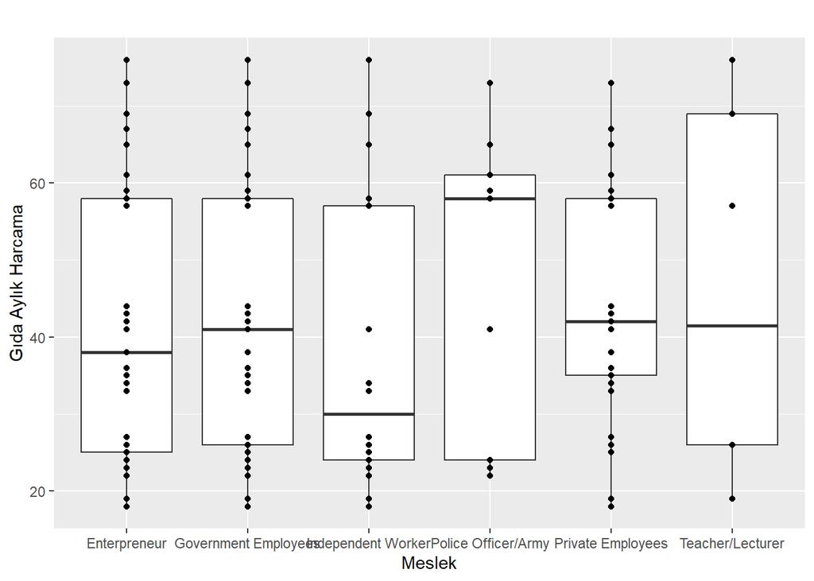

```r
library(ggplot2)
ggplot(DATASET_cultural_dimension_of_food_consumption, aes(x=`(B9) OCCUPATION`, y=`(C15) % MONTHLY EXPENDITURE FOR FOOD`))+labs(title="",x="Meslek", y = "Gıda Aylık Harcama")+
geom_boxplot()+
geom_point()
```

```r
model_DATASET<-aov(`(C15) % MONTHLY EXPENDITURE FOR FOOD`~ `(B9) OCCUPATION`, data = DATASET_cultural_dimension_of_food_consumption)
model_DATASET
```

```
## Call:
##    aov(formula = `(C15) % MONTHLY EXPENDITURE FOR FOOD` ~ `(B9) OCCUPATION`,
##     data = DATASET_cultural_dimension_of_food_consumption)
##
## Terms:
##                 `(B9) OCCUPATION` Residuals
## Sum of Squares            3961.88 202335.08
## Deg. of Freedom                 5       704
##
## Residual standard error: 16.95311
## Estimated effects may be unbalanced
```

```r
summary(model_DATASET)
```

```
##                    Df Sum Sq Mean Sq F value Pr(>F)
## `(B9) OCCUPATION`   5   3962   792.4   2.757 0.0178 *
## Residuals         704 202335   287.4
## ---
## Signif. codes:  0 '***' 0.001 '**' 0.01 '*' 0.05 '.' 0.1 ' ' 1
```

Tek-yönlü ANOVA için hipotezlerimiz aşağıdaki gibidir.
$$H_0 : \mu_1=\mu_2=\mu_3=\mu_4=\mu_5=\mu_6$$
, $H_1:$ En az bir ($i,j$) için $\mu_i \neq \mu_j$ F-istatistiğini değerine karşılık gelen p-değeri< $\alpha$ = 0.05 olduğundan $H_0$ hipotezi reddedilir.En az bir deneme için ortalama diğer denemelerin ortalamalarından farklıdır.

Yorum: Meslek faktörü, kentsel toplulukların gıda aylık harcamasında önemli bir etkiye sahiptir.

2. Rastgele Tam Blok Tasarımı

Bu veri için ilk olarak bloklama yaparak varyans analizini yapacağız. Bunun için aov fonksiyonunda hem ana (main) faktör meslek hem de bloklama faktörü din kullanacağız.

```r
DATASET_cultural_dimension_of_food_consumption$`(B5) RELIGION`<- as.factor(DATASET_cultural_dimension_of_food_consumption$`(B5) RELIGION`)
```

```r
levels(DATASET_cultural_dimension_of_food_consumption$`(B5) RELIGION`)
```

```
## [1] "Budha"      "Catholic"   "Hindu"      "Islam"      "Other"
## [6] "Protestant"
```

```r
blok_model <- aov(`(C15) % MONTHLY EXPENDITURE FOR FOOD`~  `(B5) RELIGION`+ `(B9) OCCUPATION` , data = DATASET_cultural_dimension_of_food_consumption)
summary(blok_model)
```

```
##                    Df Sum Sq Mean Sq F value Pr(>F)
## `(B5) RELIGION`     5   1810   362.0   1.263 0.2783
## `(B9) OCCUPATION`   5   4083   816.5   2.848 0.0148 *
## Residuals         699 200404   286.7
## ---
## Signif. codes:  0 '***' 0.001 '**' 0.01 '*' 0.05 '.' 0.1 ' ' 1
```

Bu sonuçlara göre faktör düzeyi yani meslek için p − value = 0.0148 < 0.05 olduğundan
$$H_0:\mu_1=\mu_2=\mu_3=\mu_4=\mu_5=\mu_6$$
veya
$$H_0 : \tau_1=\tau_2=\tau_3=\tau_4=\tau_5=\tau_6=0$$
hipotezi red edilir.

Böylece, denemeler yani burada analize dahil edilen mesleğe göre kentsel toplulukların gıda aylık harcamasında anlamlı bir farklılık vardır sonucunu elde ederiz.

Ayrıca, blok için de p − value =0.2783 > 0.05 olduğundan $H_0 :\mu_1=\mu_2=\mu_3=\mu_4 =\mu_5=\mu_6 =0$ hipotezi kabul edilir.

Dinlere göre kentsel toplulukların gıda aylık harcaması arasında anlamlı bir farklılık yoktur sonucunu elde ederiz.

Şimdi, meslek ile din faktörünün etkileşimini de ekleyerek aşağıdaki etkileşimli modeli inceleyelim.

```r
anova_occupation_religion_interaction<-aov(`(C15) % MONTHLY EXPENDITURE FOR FOOD`~ `(B5) RELIGION`+`(B5) RELIGION`:`(B9) OCCUPATION`+`(B9) OCCUPATION`, data = DATASET_cultural_dimension_of_food_consumption)
summary(anova_occupation_religion_interaction)
```

```
##                                    Df Sum Sq Mean Sq F value Pr(>F)
## `(B5) RELIGION`                     5   1810   362.0   1.264 0.2778
## `(B9) OCCUPATION`                   5   4083   816.5   2.851 0.0148 *
## `(B5) RELIGION`:`(B9) OCCUPATION`  17   5065   297.9   1.040 0.4113
## Residuals                         682 195340   286.4
## ---
## Signif. codes:  0 '***' 0.001 '**' 0.01 '*' 0.05 '.' 0.1 ' ' 1
```

Bu sonuca göre meslek `(B9) OCCUPATION` ile din `(B5) RELIGION` faktörlerinin etkileşimlerinin kentsel toplulukların gıda aylık harcaması üzerindeki etkisi $\alpha$ > 0.05 anlamlılık düzeyinde önemsizdir (anlamlı değildir).

3. Latin Kare Tasarımı

Blok Faktör olarak `(B7) EDUCATION LEVEL` ve `(B5) RELIGION` seçelim.

```r
DATASET_cultural_dimension_of_food_consumption$`(B5) RELIGION`<- as.factor(DATASET_cultural_dimension_of_food_consumption$`(B5) RELIGION`)
DATASET_cultural_dimension_of_food_consumption$`(B7) EDUCATION LEVEL`<- as.factor(DATASET_cultural_dimension_of_food_consumption$`(B7) EDUCATION LEVEL`)
```

```r
levels(DATASET_cultural_dimension_of_food_consumption$`(B7) EDUCATION LEVEL`)
```

```
## [1] "Bachelor degree"            "Diploma"
## [3] "Junior High School"         "Master and doctoral degree"
## [5] "Primary School"             "Senior High School"
```

```r
levels(DATASET_cultural_dimension_of_food_consumption$`(B5) RELIGION`)
```

```
## [1] "Budha"      "Catholic"   "Hindu"      "Islam"      "Other"
## [6] "Protestant"
```

```r
levels(DATASET_cultural_dimension_of_food_consumption$`(B9) OCCUPATION`)
```

```
## [1] "Enterpreneur"         "Government Employees" "Independent Worker"
## [4] "Police Officer/Army" "Private Employees"    "Teacher/Lecturer"
```

```r
anova_latin<-aov(`(C15) % MONTHLY EXPENDITURE FOR FOOD`~ `(B5) RELIGION` + `(B7) EDUCATION LEVEL` + `(B9) OCCUPATION`, data = DATASET_cultural_dimension_of_food_consumption)
summary(anova_latin)
```

```
##                         Df Sum Sq Mean Sq F value Pr(>F)
## `(B5) RELIGION`          5   1810   362.0   1.271 0.2745
## `(B7) EDUCATION LEVEL`   5   3155   631.0   2.216 0.0511 .
## `(B9) OCCUPATION`        5   3688   737.5   2.590 0.0248 *
## Residuals              694 197645   284.8
## ---
## Signif. codes:  0 '***' 0.001 '**' 0.01 '*' 0.05 '.' 0.1 ' ' 1
```

Bu sonuca göre

• Ana faktörümüz meslek için p − value = 0.0248 < 0.05 olduğundan
$$H_0 : \tau_1 = \tau_2 = \tau_3 = \tau_4 = \tau_5 = \tau_6 = 0$$
hipotezi reddedilir. Böylece,mesleklere göre kentsel toplulukların gıda aylık harcaması arasında anlamlı bir farklılık vardır sonucunu elde ederiz.

• Blok faktörlerimiz din ve eğitim seviyesi, din faktörün p-değeri> 0.05 olduğundan kentsel toplulukların gıda aylık harcaması üzerinde anlamlı bir etkisi olmadığını, eğitim seviyesi faktörünün p-değeri>0.05 olduğundan kentsel toplulukların gıda aylık harcaması üzerinde anlamlı bir etkisi olmadığını söyleyebiliriz.

Dolayısıyla,

Din faktörünün kentsel toplulukların gıda aylık harcaması bakımından anlamlı bir farklılık yoktur. Eğitim seviyesi faktörünün kentsel toplulukların gıda aylık harcaması bakımından anlamlı bir farklılık yoktur.

4. Tek-yönlü ANCOVA

#Ortak değişken:`(B11) HOUSEHOLD MEMBER`

```r
ancova_model<-aov(`(C15) % MONTHLY EXPENDITURE FOR FOOD` ~ `(B11) HOUSEHOLD MEMBER` + `(B9) OCCUPATION`, data = DATASET_cultural_dimension_of_food_consumption)
summary(ancova_model)
```

```
##                           Df Sum Sq Mean Sq F value Pr(>F)
## `(B11) HOUSEHOLD MEMBER`   1     76    75.8   0.263 0.6080
## `(B9) OCCUPATION`          5   3915   782.9   2.721 0.0191 *
## Residuals                703 202307   287.8
## ---
## Signif. codes:  0 '***' 0.001 '**' 0.01 '*' 0.05 '.' 0.1 ' ' 1
```

Bu sonuca göre direkt yorum yapamayız. Çünkü, düzeltilmiş kareler toplamları ile testlerimizi yapmalıyız.

Bunun için car paketindeki Anova fonksiyonunu Tip III kareler toplamları ile hesaplarız.

```r
car::Anova(aov(`(C15) % MONTHLY EXPENDITURE FOR FOOD` ~ `(B11) HOUSEHOLD MEMBER` + `(B9) OCCUPATION`, data = DATASET_cultural_dimension_of_food_consumption),type="III")
```

```
## Anova Table (Type III tests)
##
## Response: (C15) % MONTHLY EXPENDITURE FOR FOOD
##                          Sum Sq  Df F value    Pr(>F)
## (Intercept)               13080   1 45.4535 3.261e-11 ***
## `(B11) HOUSEHOLD MEMBER`     29   1  0.0992    0.7528
## `(B9) OCCUPATION`          3915   5  2.7206    0.0191 *
## Residuals                202307 703
## ---
## Signif. codes:  0 '***' 0.001 '**' 0.01 '*' 0.05 '.' 0.1 ' ' 1
```

Bu sonuca göre;

Denemeler için yani occupation faktörü için test istatistigi değeri F0 = 2.7206 ve p-degeri<0.05 olduğundan ilgili
$$H_0 :\tau_1 = \tau_2 = \tau_3 = \tau_4 = \tau_5 = \tau_6 = 0$$
hipotezi reddedilir. Böylece deneye katılanların ev üye sayısı gözönünde bulundurulduğunda kentsel toplulukların gıda aylık harcaması bakımından mesleklerin etkisinin anlamlı olduğunu elde ederiz.

Kovaryans analizine ihtiyacımız olup olmadığını veya doğru kullanıp kullanmadığımızı kontrol etmek için de $H_0 :\beta=0$ hipotezini test ederiz.

Bunun için,$\beta$ eğim parametresi household member ile monthly expenditure for food arasındaki doğrusal regresyonun eğim katsayısı olduğundan bu hipotez için F-testinin değeri yukarıdaki household member için verilen sonuçlardan $F_\beta$ =0.0992 olarak elde edilir ve p-değeri>0.05 olduğundan $H_0:\beta= 0$ kabul edilir. Dolayısıyla, ANCOVA kullanmak uygun değildir.

6. Varsayım Kontrolü

Tek-yönlü ANOVA modeli için;

• Normallik varsayımı:

Quantile-Quantile (qq) grafiği

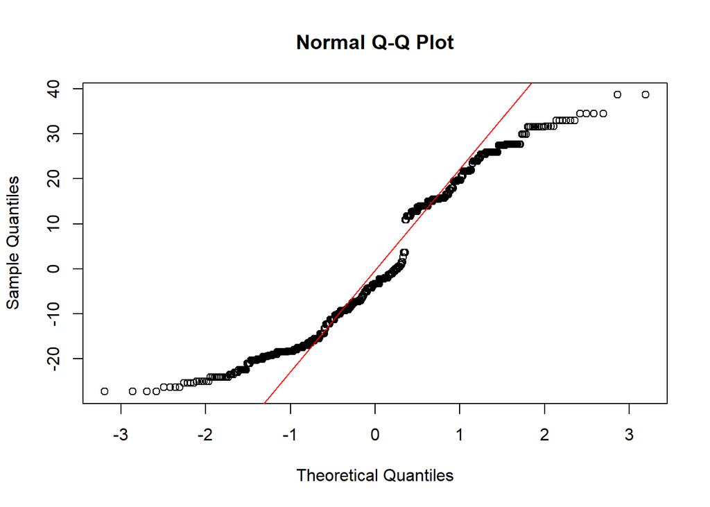

```r
qqnorm(model_DATASET$residuals)
qqline(model_DATASET$residuals,col="red")
```

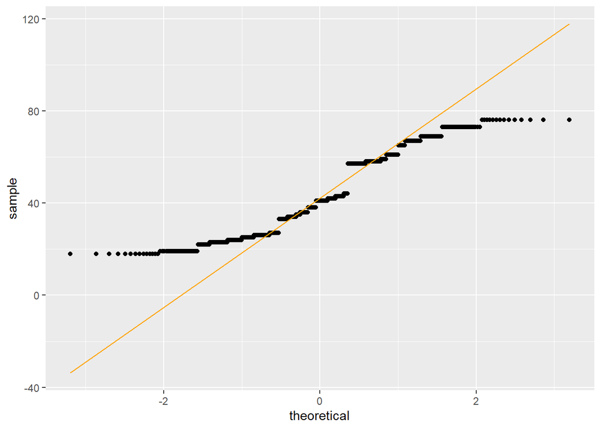

```r
library(ggplot2)
ggplot(data=DATASET_cultural_dimension_of_food_consumption, aes(sample = `(C15) % MONTHLY EXPENDITURE FOR FOOD`))+
geom_qq()+
geom_qq_line(color = "orange")
```

Grafiklere baktığımızda net bir yorum yapamayız.

#Kolmogorov-Smirnov normallik testi: Parametrelerin değerlerini bilmediğimiz için veriden tahmin ederiz.

```r
ks.test(model_DATASET$residuals,"pnorm",mean=mean(model_DATASET$residuals),sd=sd(model_DATASET$residuals))
```

```
##
##  One-sample Kolmogorov-Smirnov test
##
## data:  model_DATASET$residuals
## D = 0.11105, p-value = 4.96e-08
## alternative hypothesis: two-sided
```

#Shapiro-Wilk testi:

```r
shapiro.test(model_DATASET$residuals)
```

```
##
##  Shapiro-Wilk normality test
##
## data:  model_DATASET$residuals
## W = 0.9369, p-value < 2.2e-16
```

#Lilliefors (Kolmogorov-Smirnov) normality test:

```r
nortest::lillie.test(residuals(model_DATASET))
```

```
##
##  Lilliefors (Kolmogorov-Smirnov) normality test
##
## data:  residuals(model_DATASET)
## D = 0.11105, p-value < 2.2e-16
```

#Cramer-von Mises test for normality:

```r
goftest::cvm.test(model_DATASET$residuals)
```

```
##
##  Cramer-von Mises test of goodness-of-fit
##  Null hypothesis: uniform distribution
##  Parameters assumed to be fixed
##
## data:  model_DATASET$residuals
## omega2 = 65.861, p-value < 2.2e-16
```

p-value < 0.05 olduğundan $H_0$ reddedilir. Artıklar normal dağılıma sahip değildir.Normallik varsayımı sağlanmamaktadır.

#Homojen varyanslılık kontrolü:

#Bartlett Test:

```r
bartlett.test(resid(model_DATASET) ~ `(B9) OCCUPATION`, data=DATASET_cultural_dimension_of_food_consumption)
```

```
##
##  Bartlett test of homogeneity of variances
##
## data:  resid(model_DATASET) by (B9) OCCUPATION
## Bartlett's K-squared = 12.81, df = 5, p-value = 0.02522
```

$H_0$ reddedilir. Denemelerin varyanslarının homojen olduğu hipotezi reddedilir.

#Levene Test:

```r
car::leveneTest(resid(model_DATASET) ~ `(B9) OCCUPATION`, data=DATASET_cultural_dimension_of_food_consumption)
```

```
## Levene's Test for Homogeneity of Variance (center = median)
##        Df F value    Pr(>F)
## group   5  4.8963 0.0002062 ***
##       704
## ---
## Signif. codes:  0 '***' 0.001 '**' 0.01 '*' 0.05 '.' 0.1 ' ' 1
```

$H_0$ reddedilir. Denemelerin varyanslarının homojen olduğu hipotezi kabul edilemez. Artıklar için homojen varyanslılık varsayımı sağlanmamaktadır.

• Box-Cox dönüşümü uygulayalım.

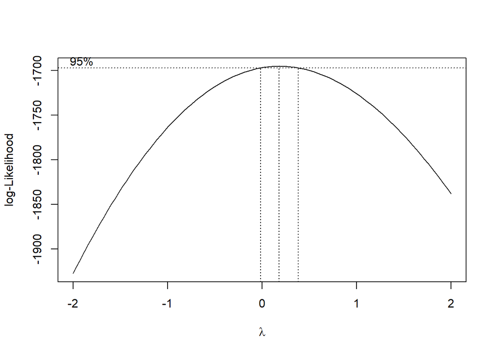

```r
bc<-MASS::boxcox(model_DATASET)
```

```r
lambda <- bc$x[which.max(bc$y)]
lambda
```

```
## [1] 0.1818182
```

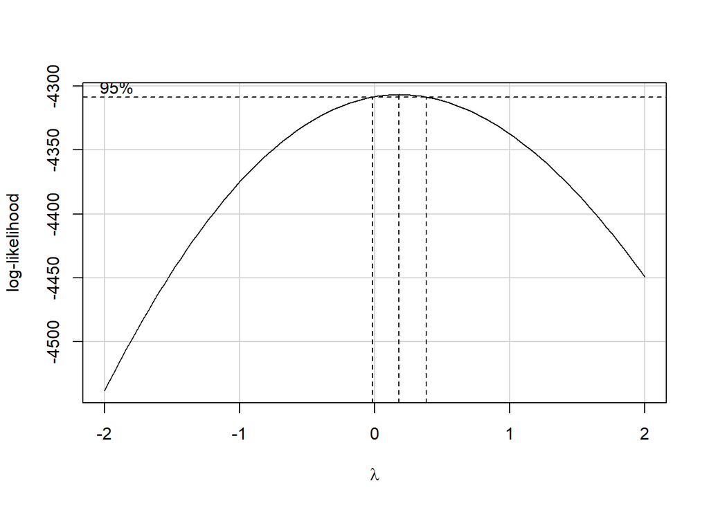

```r
A1<-car::boxCox(model_DATASET, family="bcPower", plotit = TRUE)
```

```r
lambda1<-A1$x[which.max(A1$y)]
lambda1
```

```
## [1] 0.1818182
```

```r
T1<-cellWise::transfo(DATASET_cultural_dimension_of_food_consumption$`(C15) % MONTHLY EXPENDITURE FOR FOOD`, type = "BC", robust = FALSE)
```

```
##
##  The input data has 710 rows and 1 columns.
```

```r
T1$lambdahats
```

```
## [1] 0.2149362
```

1.Dönüşüm

0.1818182 değerini kullanarak `(C15) % MONTHLY EXPENDITURE FOR FOOD` değişkeni üzerinde dönüşüm yapalım ve ANOVA modelini oluşturarak, varsayımları kontrol edelim.

```r
model2_DATASET<-aov((`(C15) % MONTHLY EXPENDITURE FOR FOOD`^lambda1)~`(B9) OCCUPATION`, data=DATASET_cultural_dimension_of_food_consumption)
model2_DATASET
```

```
## Call:
##    aov(formula = (`(C15) % MONTHLY EXPENDITURE FOR FOOD`^lambda1) ~
##     `(B9) OCCUPATION`, data = DATASET_cultural_dimension_of_food_consumption)
##
## Terms:
##                 `(B9) OCCUPATION` Residuals
## Sum of Squares           0.389112 14.932950
## Deg. of Freedom                 5       704
##
## Residual standard error: 0.1456419
## Estimated effects may be unbalanced
```

```r
summary(model2_DATASET)
```

```
##                    Df Sum Sq Mean Sq F value  Pr(>F)
## `(B9) OCCUPATION`   5  0.389 0.07782   3.669 0.00277 **
## Residuals         704 14.933 0.02121
## ---
## Signif. codes:  0 '***' 0.001 '**' 0.01 '*' 0.05 '.' 0.1 ' ' 1
```

• Varsayımların kontrolü:

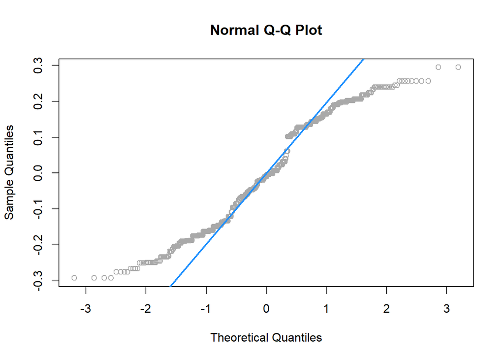

```r
qqnorm(resid(model2_DATASET), main = "Normal Q-Q Plot", col = "darkgrey")
qqline(resid(model2_DATASET), col = "dodgerblue", lwd = 2)
```

```r
shapiro.test(residuals(model2_DATASET))
```

```
##
##  Shapiro-Wilk normality test
##
## data:  residuals(model2_DATASET)
## W = 0.95799, p-value = 2.249e-13
```

```r
nortest::lillie.test(residuals(model2_DATASET))
```

```
##
##  Lilliefors (Kolmogorov-Smirnov) normality test
##
## data:  residuals(model2_DATASET)
## D = 0.11975, p-value < 2.2e-16
```

```r
ks.test(scale(residuals(model2_DATASET)), "pnorm")
```

```
##
##  One-sample Kolmogorov-Smirnov test
##
## data:  scale(residuals(model2_DATASET))
## D = 0.11975, p-value = 2.87e-09
## alternative hypothesis: two-sided
```

Hatalar normallik varsayımını sağlamamaktadır.

```r
bartlett.test((`(C15) % MONTHLY EXPENDITURE FOR FOOD`^lambda1)~`(B9) OCCUPATION`, data=DATASET_cultural_dimension_of_food_consumption)
```

```
##
##  Bartlett test of homogeneity of variances
##
## data:  (`(C15) % MONTHLY EXPENDITURE FOR FOOD`^lambda1) by (B9) OCCUPATION
## Bartlett's K-squared = 16.844, df = 5, p-value = 0.004805
```

```r
car::leveneTest((`(C15) % MONTHLY EXPENDITURE FOR FOOD`^lambda1)~`(B9) OCCUPATION`, data=DATASET_cultural_dimension_of_food_consumption)
```

```
## Levene's Test for Homogeneity of Variance (center = median)
##        Df F value   Pr(>F)
## group   5  7.4646 7.74e-07 ***
##       704
## ---
## Signif. codes:  0 '***' 0.001 '**' 0.01 '*' 0.05 '.' 0.1 ' ' 1
```

Homojen varyanslılık varsayımı sağlanmamaktadır.

2.Dönüşüm

0.2149362 değerini kullanarak `(C15) % MONTHLY EXPENDITURE FOR FOOD` değişkeni üzerinde dönüşüm yapalım ve ANOVA modelini oluşturarak, varsayımları kontrol edelim.

```r
model3_DATASET<-aov( (`(C15) % MONTHLY EXPENDITURE FOR FOOD`^(T1$lambdahats))~`(B9) OCCUPATION`, data=DATASET_cultural_dimension_of_food_consumption)
model3_DATASET
```

```
## Call:
##    aov(formula = (`(C15) % MONTHLY EXPENDITURE FOR FOOD`^(T1$lambdahats)) ~
##     `(B9) OCCUPATION`, data = DATASET_cultural_dimension_of_food_consumption)
##
## Terms:
##                 `(B9) OCCUPATION` Residuals
## Sum of Squares           0.686114 26.628474
## Deg. of Freedom                 5       704
##
## Residual standard error: 0.1944853
## Estimated effects may be unbalanced
```

```r
summary(model3_DATASET)
```

```
##                    Df Sum Sq Mean Sq F value  Pr(>F)
## `(B9) OCCUPATION`   5  0.686 0.13722   3.628 0.00301 **
## Residuals         704 26.628 0.03782
## ---
## Signif. codes:  0 '***' 0.001 '**' 0.01 '*' 0.05 '.' 0.1 ' ' 1
```

• Varsayımların kontrolü:

```r
shapiro.test(residuals(model3_DATASET))
```

```
##
##  Shapiro-Wilk normality test
##
## data:  residuals(model3_DATASET)
## W = 0.9575, p-value = 1.829e-13
```

```r
nortest::lillie.test(residuals(model3_DATASET))
```

```
##
##  Lilliefors (Kolmogorov-Smirnov) normality test
##
## data:  residuals(model3_DATASET)
## D = 0.1199, p-value < 2.2e-16
```

```r
ks.test(scale(residuals(model3_DATASET)), "pnorm")
```

```
##
##  One-sample Kolmogorov-Smirnov test
##
## data:  scale(residuals(model3_DATASET))
## D = 0.1199, p-value = 2.73e-09
## alternative hypothesis: two-sided
```

Hatalar normallik varsayımını sağlamamaktadır.

```r
bartlett.test((`(C15) % MONTHLY EXPENDITURE FOR FOOD`^(T1$lambdahats))~`(B9) OCCUPATION`, data=DATASET_cultural_dimension_of_food_consumption)
```

```
##
##  Bartlett test of homogeneity of variances
##
## data:  (`(C15) % MONTHLY EXPENDITURE FOR FOOD`^(T1$lambdahats)) by (B9) OCCUPATION
## Bartlett's K-squared = 16.665, df = 5, p-value = 0.00518
```

```r
car::leveneTest((`(C15) % MONTHLY EXPENDITURE FOR FOOD`^(T1$lambdahats))~`(B9) OCCUPATION`, data=DATASET_cultural_dimension_of_food_consumption)
```

```
## Levene's Test for Homogeneity of Variance (center = median)
##        Df F value    Pr(>F)
## group   5  7.3642 9.646e-07 ***
##       704
## ---
## Signif. codes:  0 '***' 0.001 '**' 0.01 '*' 0.05 '.' 0.1 ' ' 1
```

Homojen varyanslılık varsayımı sağlanmamaktadır.

5. İkili ve Çoklu Karşılaştırmalar

Tek-yönlü ANOVA için:

Scheffe yöntemi ile tüm mümkün ikili karşılaştırmaları yapabiliriz.

```r
library(agricolae)
scheffe_out1<-scheffe.test(model_DATASET,"(B9) OCCUPATION",group=TRUE)
scheffe_out1
```

```
## $statistics
##    MSerror  Df        F     Mean       CV
##   287.4078 704 2.226828 42.99296 39.43228
##
## $parameters
##      test          name.t ntr alpha
##   Scheffe (B9) OCCUPATION   6  0.05
##
## $means
##                      (C15) % MONTHLY EXPENDITURE FOR FOOD      std   r Min Max
## Enterpreneur                                     41.49741 17.77144 193  18  76
## Government Employees                             43.03960 17.12519 202  18  76
## Independent Worker                               37.33333 17.41290  60  18  76
## Police Officer/Army                              47.06667 19.22809  30  22  73
## Private Employees                                45.27805 14.76501 205  18  73
## Teacher/Lecturer                                 44.40000 22.55380  20  19  76
##                      Q25  Q50 Q75
## Enterpreneur          25 38.0  58
## Government Employees  26 41.0  58
## Independent Worker    24 30.0  57
## Police Officer/Army   24 58.0  61
## Private Employees     35 42.0  58
## Teacher/Lecturer      26 41.5  69
##
## $comparison
## NULL
##
## $groups
##                      (C15) % MONTHLY EXPENDITURE FOR FOOD groups
## Police Officer/Army                              47.06667      a
## Private Employees                                45.27805      a
## Teacher/Lecturer                                 44.40000      a
## Government Employees                             43.03960      a
## Enterpreneur                                     41.49741      a
## Independent Worker                               37.33333      a
##
## attr(,"class")
## [1] "group"
```

Bu sonuca göre $groups altında aynı harfler ile gösterilenler arasında anlamlı bir fark bulunmamaktadır.Böylece, tüm grupların alındığı kitlelerin ortalamaları arasında anlamlı bir farklılık bulunmamaktadır diyebiliriz.

• HSD.test{agricolae}

```r
hsd_out<-HSD.test(model_DATASET,"(B9) OCCUPATION",group=FALSE)
hsd_out
```

```
## $statistics
##    MSerror  Df     Mean       CV
##   287.4078 704 42.99296 39.43228
##
## $parameters
##    test          name.t ntr StudentizedRange alpha
##   Tukey (B9) OCCUPATION   6         4.041235  0.05
##
## $means
##                      (C15) % MONTHLY EXPENDITURE FOR FOOD      std   r Min Max
## Enterpreneur                                     41.49741 17.77144 193  18  76
## Government Employees                             43.03960 17.12519 202  18  76
## Independent Worker                               37.33333 17.41290  60  18  76
## Police Officer/Army                              47.06667 19.22809  30  22  73
## Private Employees                                45.27805 14.76501 205  18  73
## Teacher/Lecturer                                 44.40000 22.55380  20  19  76
##                      Q25  Q50 Q75
## Enterpreneur          25 38.0  58
## Government Employees  26 41.0  58
## Independent Worker    24 30.0  57
## Police Officer/Army   24 58.0  61
## Private Employees     35 42.0  58
## Teacher/Lecturer      26 41.5  69
##
## $comparison
##                                            difference pvalue signif.        LCL
## Enterpreneur - Government Employees        -1.5421946 0.9455          -6.418518
## Enterpreneur - Independent Worker           4.1640760 0.5577          -2.996605
## Enterpreneur - Police Officer/Army         -5.5692573 0.5496         -15.076651
## Enterpreneur - Private Employees           -3.7806395 0.2282          -8.639498
## Enterpreneur - Teacher/Lecturer            -2.9025907 0.9784         -14.282649
## Government Employees - Independent Worker   5.7062706 0.1997          -1.416479
## Government Employees - Police Officer/Army -4.0270627 0.8301         -13.505920
## Government Employees - Private Employees   -2.2384448 0.7672          -7.041227
## Government Employees - Teacher/Lecturer    -1.3603960 0.9994         -12.716625
## Independent Worker - Police Officer/Army   -9.7333333 0.1067         -20.565949
## Independent Worker - Private Employees     -7.9447154 0.0184       * -15.055519
## Independent Worker - Teacher/Lecturer      -7.0666667 0.5892         -19.575094
## Police Officer/Army - Private Employees     1.7886179 0.9945          -7.681267
## Police Officer/Army - Teacher/Lecturer      2.6666667 0.9943         -11.318180
```

[output cut: 8 more lines]

```
## Government Employees - Police Officer/Army  5.4517950
## Government Employees - Private Employees    2.5643376
## Government Employees - Teacher/Lecturer     9.9958326
## Independent Worker - Police Officer/Army    1.0992821
## Independent Worker - Private Employees     -0.8339115
## Independent Worker - Teacher/Lecturer       5.4417602
## Police Officer/Army - Private Employees    11.2585027
## Police Officer/Army - Teacher/Lecturer     16.6515131
## Private Employees - Teacher/Lecturer       12.2267890
##
## $groups
## NULL
##
## attr(,"class")
## [1] "group"
```

• Eğer testin sonucunda hesaplanan p-degeri> $\alpha$ olur ise $H_0$ hipotezi kabul edilir. Böylece karşılaştırılan gruplar arasında anlamlı bir farklılık olmadığı sonucunu elde ederiz.

• Eğer p-değeri< $\alpha$ olur ise $H_0$ hipotezi reddedilir. Böylece karşılaştırılan gruplar arasında anlamlı bir farklılık olduğu sonucunu elde ederiz.

Baktığımızda Independent Worker - Private Employees gruplarının p-değerinin 0.05 den küçük olduğunu görmekteyiz bu nedenle $H_0$ hipotezi reddedilir. Böylece karşılaştırılan gruplar arasında anlamlı bir farklılık olduğu sonucunu elde ederiz.

• Fisher LSD Test

```r
lsd_out<-LSD.test(model_DATASET,"(B9) OCCUPATION",group=FALSE)
lsd_out
```

```
## $statistics
##    MSerror  Df     Mean       CV
##   287.4078 704 42.99296 39.43228
##
## $parameters
##         test p.ajusted          name.t ntr alpha
##   Fisher-LSD      none (B9) OCCUPATION   6  0.05
##
## $means
##                      (C15) % MONTHLY EXPENDITURE FOR FOOD      std   r      LCL
## Enterpreneur                                     41.49741 17.77144 193 39.10152
## Government Employees                             43.03960 17.12519 202 40.69770
## Independent Worker                               37.33333 17.41290  60 33.03630
## Police Officer/Army                              47.06667 19.22809  30 40.98974
## Private Employees                                45.27805 14.76501 205 42.95334
## Teacher/Lecturer                                 44.40000 22.55380  20 36.95731
##                           UCL Min Max Q25  Q50 Q75
## Enterpreneur         43.89329  18  76  25 38.0  58
## Government Employees 45.38151  18  76  26 41.0  58
## Independent Worker   41.63037  18  76  24 30.0  57
## Police Officer/Army  53.14359  22  73  24 58.0  61
## Private Employees    47.60275  18  73  35 42.0  58
## Teacher/Lecturer     51.84269  19  76  26 41.5  69
##
## $comparison
##                                            difference pvalue signif.
## Enterpreneur - Government Employees        -1.5421946 0.3664
## Enterpreneur - Independent Worker           4.1640760 0.0970       .
## Enterpreneur - Police Officer/Army         -5.5692573 0.0946       .
## Enterpreneur - Private Employees           -3.7806395 0.0265       *
## Enterpreneur - Teacher/Lecturer            -2.9025907 0.4663
## Government Employees - Independent Worker   5.7062706 0.0224       *
## Government Employees - Police Officer/Army -4.0270627 0.2251
## Government Employees - Private Employees   -2.2384448 0.1833
## Government Employees - Teacher/Lecturer    -1.3603960 0.7322
## Independent Worker - Police Officer/Army   -9.7333333 0.0104       *
## Independent Worker - Private Employees     -7.9447154 0.0015      **
## Independent Worker - Teacher/Lecturer      -7.0666667 0.1069
## Police Officer/Army - Private Employees     1.7886179 0.5896
## Police Officer/Army - Teacher/Lecturer      2.6666667 0.5860
```

[output cut: 8 more lines]

```
## Government Employees - Police Officer/Army -10.5396315  2.4855061
## Government Employees - Private Employees    -5.5382571  1.0613675
## Government Employees - Teacher/Lecturer     -9.1628363  6.4420442
## Independent Worker - Police Officer/Army   -17.1760185 -2.2906482
## Independent Worker - Private Employees     -12.8302831 -3.0591478
## Independent Worker - Teacher/Lecturer      -15.6607392  1.5274059
## Police Officer/Army - Private Employees     -4.7177860  8.2950218
## Police Officer/Army - Teacher/Lecturer      -6.9417986 12.2751319
## Private Employees - Teacher/Lecturer        -6.9192464  8.6753440
##
## $groups
## NULL
##
## attr(,"class")
## [1] "group"
```

Enterpreneur - Private Employees, Government Employees - Independent Worker, Independent Worker - Police Officer/Army, Independent Worker - Private Employees gruplarının p-değerinin 0.05 den küçük olduğunu görmekteyiz bu nedenle $H_0$ hipotezi reddedilir. Böylece karşılaştırılan gruplar arasında anlamlı bir farklılık olduğu sonucunu elde ederiz.

• duncan.test {agricolae}

```r
duncan_out<-duncan.test(model_DATASET, "(B9) OCCUPATION",group=FALSE)
duncan_out
```

```
## $statistics
##    MSerror  Df     Mean       CV
##   287.4078 704 42.99296 39.43228
##
## $parameters
##     test          name.t ntr alpha
##   Duncan (B9) OCCUPATION   6  0.05
##
## $duncan
## NULL
##
## $means
##                      (C15) % MONTHLY EXPENDITURE FOR FOOD      std   r Min Max
## Enterpreneur                                     41.49741 17.77144 193  18  76
## Government Employees                             43.03960 17.12519 202  18  76
## Independent Worker                               37.33333 17.41290  60  18  76
## Police Officer/Army                              47.06667 19.22809  30  22  73
## Private Employees                                45.27805 14.76501 205  18  73
## Teacher/Lecturer                                 44.40000 22.55380  20  19  76
##                      Q25  Q50 Q75
## Enterpreneur          25 38.0  58
## Government Employees  26 41.0  58
## Independent Worker    24 30.0  57
## Police Officer/Army   24 58.0  61
## Private Employees     35 42.0  58
## Teacher/Lecturer      26 41.5  69
##
## $comparison
##                                            difference pvalue signif.        LCL
## Enterpreneur - Government Employees        -1.5421946 0.6424          -8.059253
## Enterpreneur - Independent Worker           4.1640760 0.2101          -2.352982
## Enterpreneur - Police Officer/Army         -5.5692573 0.1382         -12.831097
## Enterpreneur - Private Employees           -3.7806395 0.3058         -10.872303
## Enterpreneur - Teacher/Lecturer            -2.9025907 0.4140          -9.763895
## Government Employees - Independent Worker   5.7062706 0.1049          -1.155034
## Government Employees - Police Officer/Army -4.0270627 0.2748         -11.118726
## Government Employees - Private Employees   -2.2384448 0.5294          -9.099750
## Government Employees - Teacher/Lecturer    -1.3603960 0.6821          -7.877454
## Independent Worker - Police Officer/Army   -9.7333333 0.0082      ** -17.128455
## Independent Worker - Private Employees     -7.9447154 0.0310       * -15.206556
```

[output cut: 11 more lines]

```
## Government Employees - Police Officer/Army  3.06460064
## Government Employees - Private Employees    4.62286000
## Government Employees - Teacher/Lecturer     5.15666231
## Independent Worker - Police Officer/Army   -2.33821207
## Independent Worker - Private Employees     -0.68287537
## Independent Worker - Teacher/Lecturer       0.02499668
## Police Officer/Army - Private Employees     8.30567624
## Police Officer/Army - Teacher/Lecturer      9.52797148
## Private Employees - Teacher/Lecturer        7.39510713
##
## $groups
## NULL
##
## attr(,"class")
## [1] "group"
```

Independent Worker - Police Officer/Army, Independent Worker - Private Employees, gruplarının p-değerinin 0.05 den küçük olduğunu görmekteyiz bu nedenle $H_0$ hipotezi reddedilir. Böylece karşılaştırılan gruplar arasında anlamlı bir farklılık olduğu sonucunu elde ederiz.